# Drake_Zhou_Part_03_D_01

Drake Zhou

4/26/2022

# Overview & Initialization

## Package Import

```r
library(tidyverse)
library(caret)
library(coefplot)
library(rstanarm)
library(splines)
```

## Data Import

```r
df_all <- readr::read_csv("final_project_train.csv", col_names = TRUE)
# Input standarize
standard_df_all <- df_all %>%
  select(starts_with("x")) %>%
  # scale(center = TRUE, scale = TRUE) %>%
  # as.data.frame() %>%
  # tibble::as_tibble() %>%
  mutate(obs = factor(df_all$outcome, levels = c("event", "non_event")),
         region = df_all$region,
         customer = df_all$customer)

# Resampling
train_id <- sample(1:nrow(standard_df_all), size = floor(0.8 * nrow(standard_df_all)))
train_ready <- standard_df_all %>% slice(train_id)
test_ready <- standard_df_all %>% slice(-train_id)
```

# Model Training

You must train, evaluate, tune, and compare simple to complex models via resampling.• You may use either caret or tidymodels to handle the preprocessing, training, testing, and evaluation. You must decide the resampling scheme, what kind of preprocessing options you should consider.

## Training parameter

```r
my_ctrl <- trainControl(method = "repeatedcv", number = 5, repeats = 3)
my_metric <- "Accuracy"
```

You must train and tune the following models: • Generalized linear models: • All categorical and continuous inputs - linear additive features • All pairwise interactions of continuous inputs, include additive categorical features • The 2 models selected from iiiA)

## Linear models

```r
set.seed(1024)
fit_acc_cat_lm_add <- train(obs ~ .,
                  data = standard_df_all,
                  method = "glm",
                  metric = my_metric,
                  preProcess = c("center", "scale"),
                  trControl = my_ctrl)

fit_acc_cat_lm_add
```

```
## Generalized Linear Model
##
## 677 samples
##  35 predictor
##   2 classes: 'event', 'non_event'
##
## Pre-processing: centered (43), scaled (43)
## Resampling: Cross-Validated (5 fold, repeated 3 times)
## Summary of sample sizes: 542, 541, 542, 542, 541, 542, ...
## Resampling results:
##
##   Accuracy   Kappa
##   0.8321423  0.3791471
```

```r
set.seed(1024)
fit_acc_cat_lm_pair <- train(obs ~ region + customer + (.)^2,
                  data = standard_df_all,
                  method = "glm",
                  metric = my_metric,
                  preProcess = c("center", "scale"),
                  trControl = my_ctrl)

fit_acc_cat_lm_pair
```

```
## Generalized Linear Model
##
## 677 samples
##  35 predictor
##   2 classes: 'event', 'non_event'
##
## Pre-processing: centered (917), scaled (917)
## Resampling: Cross-Validated (5 fold, repeated 3 times)
## Summary of sample sizes: 542, 541, 542, 542, 541, 542, ...
## Resampling results:
##
##   Accuracy   Kappa
##   0.5125163  0.02379704
```

```r
set.seed(1024)
fit_acc_cat_lm_mod1 <- train(obs ~ region + customer,
                  data = standard_df_all,
                  method = "glm",
                  metric = my_metric,
                  preProcess = c("center", "scale"),
                  trControl = my_ctrl)

fit_acc_cat_lm_mod1
```

```
## Generalized Linear Model
##
## 677 samples
##   2 predictor
##   2 classes: 'event', 'non_event'
##
## Pre-processing: centered (10), scaled (10)
## Resampling: Cross-Validated (5 fold, repeated 3 times)
## Summary of sample sizes: 542, 541, 542, 542, 541, 542, ...
## Resampling results:
##
##   Accuracy   Kappa
##   0.8124183  0
```

```r
set.seed(1024)
fit_acc_cat_lm_mod2 <- train(obs ~ .,
                  data = standard_df_all[c(-36, -35)],
                  method = "glm",
                  metric = my_metric,
                  preProcess = c("center", "scale"),
                  trControl = my_ctrl)

fit_acc_cat_lm_mod2
```

```
## Generalized Linear Model
##
## 677 samples
##  33 predictor
##   2 classes: 'event', 'non_event'
##
## Pre-processing: centered (33), scaled (33)
## Resampling: Cross-Validated (5 fold, repeated 3 times)
## Summary of sample sizes: 542, 541, 542, 542, 541, 542, ...
## Resampling results:
##
##   Accuracy   Kappa
##   0.8375527  0.3886865
```

## Elastic Net models

• Regularized logistic regression with Elastic net • All pairwise interactions of continuous inputs, include additive categorical features • The more complex of the 2 models selected from iiA)

```r
set.seed(1024)
fit_acc_cat_enet_pair <- train(obs ~ region + customer + (.)^2,
                               data = standard_df_all,
                               method = "glmnet",
                               metric = my_metric,
                               preProcess = c("center", "scale"),
                               trControl = my_ctrl)

fit_acc_cat_enet_pair
```

```
## glmnet
##
## 677 samples
##  35 predictor
##   2 classes: 'event', 'non_event'
##
## Pre-processing: centered (917), scaled (917)
## Resampling: Cross-Validated (5 fold, repeated 3 times)
## Summary of sample sizes: 542, 541, 542, 542, 541, 542, ...
## Resampling results across tuning parameters:
##
##   alpha  lambda      Accuracy   Kappa
##   0.10   0.01039198  0.8144336  0.32946917
##   0.10   0.03286232  0.8252469  0.32923421
##   0.10   0.10391977  0.8282026  0.26772141
##   0.55   0.01039198  0.8232680  0.31686994
##   0.55   0.03286232  0.8296623  0.26315257
##   0.55   0.10391977  0.8183188  0.08665501
##   1.00   0.01039198  0.8281845  0.30940553
##   1.00   0.03286232  0.8252288  0.21147410
##   1.00   0.10391977  0.8138925  0.01215829
##
## Accuracy was used to select the optimal model using the largest value.
## The final values used for the model were alpha = 0.55 and lambda = 0.03286232.
```

```r
formula_mod7 <- obs ~ poly(xb_01, 2)+poly(xb_02, 2)+ poly(xb_03,2)+poly(xn_01,2)+poly(xn_02,2)+poly(xn_03,2)+poly(xa_01,2)+poly(xa_02,2)+poly(xa_03,2)+poly(xb_04,2)+poly(xb_05,2)+poly(xb_06,2)+poly(xb_07,2)+poly(xb_08,2)+poly(xn_04,2)+poly(xn_05,2)+poly(xn_06,2)+poly(xn_07,2)+poly(xn_08,2)+poly(xa_04,2)+poly(xa_05,2)+poly(xa_06,2)+poly(xa_07,2)+poly(xa_08,2)+poly(xw_01,2)+poly(xw_02,2)+poly(xw_03,2)+poly(xs_01,2)+poly(xs_02,2)+poly(xs_03,2)+poly(xs_04,2)+poly(xs_05,2)+poly(xs_06,2)+region+customer

set.seed(1024)
fit_acc_cat_enet_mod7 <- train(formula_mod7,
                       data = standard_df_all,
                       method = "glmnet",
                       metric = my_metric,
                       preProcess = c("center", "scale"),
                       trControl = my_ctrl)

fit_acc_cat_enet_mod7
```

```
## glmnet
##
## 677 samples
##  35 predictor
##   2 classes: 'event', 'non_event'
##
## Pre-processing: centered (76), scaled (76)
## Resampling: Cross-Validated (5 fold, repeated 3 times)
## Summary of sample sizes: 542, 541, 542, 542, 541, 542, ...
## Resampling results across tuning parameters:
##
##   alpha  lambda        Accuracy   Kappa
##   0.10   0.0003286232  0.8050399  0.3244012
##   0.10   0.0032862318  0.8291757  0.3613500
##   0.10   0.0328623182  0.8355955  0.3102633
##   0.55   0.0003286232  0.8050436  0.3243194
##   0.55   0.0032862318  0.8272113  0.3355043
##   0.55   0.0328623182  0.8242593  0.2206377
##   1.00   0.0003286232  0.8055410  0.3241135
##   1.00   0.0032862318  0.8281845  0.3249641
##   1.00   0.0328623182  0.8232462  0.1978584
##
## Accuracy was used to select the optimal model using the largest value.
## The final values used for the model were alpha = 0.1 and lambda = 0.03286232.
```

```r
formula_mod9 <- obs ~ ns(xb_01, 3)+ns(xb_03, 3)+ ns(xb_03,3)+ns(xn_01,3)+ns(xn_03,3)+ns(xn_03,3)+ns(xa_01,3)+ns(xa_03,3)+ns(xa_03,3)+ns(xb_04,3)+ns(xb_05,3)+ns(xb_06,3)+ns(xb_07,3)+ns(xb_08,3)+ns(xn_04,3)+ns(xn_05,3)+ns(xn_06,3)+ns(xn_07,3)+ns(xn_08,3)+ns(xa_04,3)+ns(xa_05,3)+ns(xa_06,3)+ns(xa_07,3)+ns(xa_08,3)+ns(xw_01,3)+ns(xw_03,3)+ns(xw_03,3)+ns(xs_01,3)+ns(xs_03,3)+ns(xs_03,3)+ns(xs_04,3)+ns(xs_05,3)+ns(xs_06,3)+region+customer

set.seed(1024)
fit_acc_cat_enet_mod9 <- train(formula_mod9,
                       data = standard_df_all,
                       method = "glmnet",
                       metric = my_metric,
                       preProcess = c("center", "scale"),
                       trControl = my_ctrl)

fit_acc_cat_enet_mod9
```

```
## glmnet
##
## 677 samples
##  30 predictor
##   2 classes: 'event', 'non_event'
##
## Pre-processing: centered (94), scaled (94)
## Resampling: Cross-Validated (5 fold, repeated 3 times)
## Summary of sample sizes: 542, 541, 542, 542, 541, 542, ...
## Resampling results across tuning parameters:
##
##   alpha  lambda        Accuracy   Kappa
##   0.10   0.0003458016  0.8065178  0.3264503
##   0.10   0.0034580162  0.8154031  0.3160195
##   0.10   0.0345801621  0.8272113  0.3013860
##   0.55   0.0003458016  0.8040595  0.3187837
##   0.55   0.0034580162  0.8168809  0.3134381
##   0.55   0.0345801621  0.8242593  0.2395886
##   1.00   0.0003458016  0.8040668  0.3206432
##   1.00   0.0034580162  0.8183442  0.3116290
##   1.00   0.0345801621  0.8232825  0.2110481
##
## Accuracy was used to select the optimal model using the largest value.
## The final values used for the model were alpha = 0.1 and lambda = 0.03458016.
```

## Neural network

Fit the model as a warmup, then use parameters to further tune this model.

```r
set.seed(1024)

fit_acc_cat_nnet_warmup <- train(obs ~ .,
                    data = standard_df_all,
                    method = "nnet",
                    metric = my_metric,
                    preProcess = c("center", "scale"),
                    trControl = my_ctrl,
                    trace = FALSE)

fit_acc_cat_nnet_warmup
```

```
## Neural Network
##
## 677 samples
##  35 predictor
##   2 classes: 'event', 'non_event'
##
## Pre-processing: centered (43), scaled (43)
## Resampling: Cross-Validated (5 fold, repeated 3 times)
## Summary of sample sizes: 542, 541, 542, 542, 541, 542, ...
## Resampling results across tuning parameters:
##
##   size  decay  Accuracy   Kappa
##   1     0e+00  0.7523566  0.2144343
##   1     1e-04  0.7405701  0.2581488
##   1     1e-01  0.8188526  0.4005672
##   3     0e+00  0.7986275  0.3510216
##   3     1e-04  0.7946659  0.3501651
##   3     1e-01  0.7971895  0.3388424
##   5     0e+00  0.7872948  0.3024006
##   5     1e-04  0.8025962  0.3665199
##   5     1e-01  0.7956609  0.3164715
##
## Accuracy was used to select the optimal model using the largest value.
## The final values used for the model were size = 1 and decay = 0.1.
```

Visualize the result and find tuning parameters

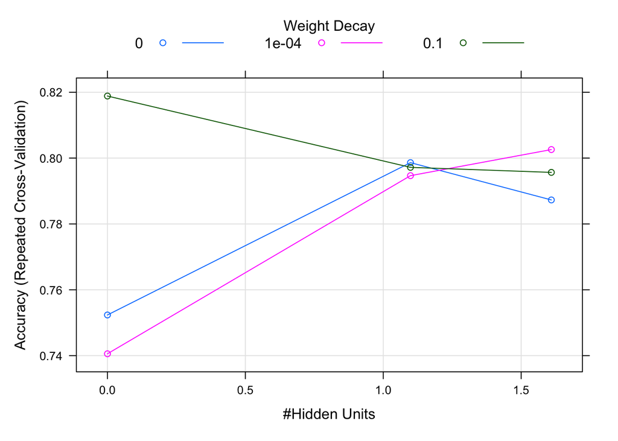

```r
plot(fit_acc_cat_nnet_warmup, xTrans = log)
```

```r
tune_grid_neural <- expand.grid(size = c(1:5, 10),
                                decay = c(0, 0.05, 0.1, 1, 2))

fit_acc_cat_nnet_tune <- train(obs ~ .,
                    data = standard_df_all,
                    method = "nnet",
                    metric = my_metric,
                    tuneGrid = tune_grid_neural,
                    preProcess = c("center", "scale"),
                    trControl = my_ctrl,
                    trace = FALSE)
```

Check the result

```r
fit_acc_cat_nnet_tune
```

```
## Neural Network
##
## 677 samples
##  35 predictor
##   2 classes: 'event', 'non_event'
##
## Pre-processing: centered (43), scaled (43)
## Resampling: Cross-Validated (5 fold, repeated 3 times)
## Summary of sample sizes: 542, 541, 542, 542, 541, 542, ...
## Resampling results across tuning parameters:
##
##   size  decay  Accuracy   Kappa
##    1    0.00   0.7434386  0.2886332
##    1    0.05   0.8050690  0.3972418
##    1    0.10   0.8168845  0.3878542
```

[output cut: 30 more lines]

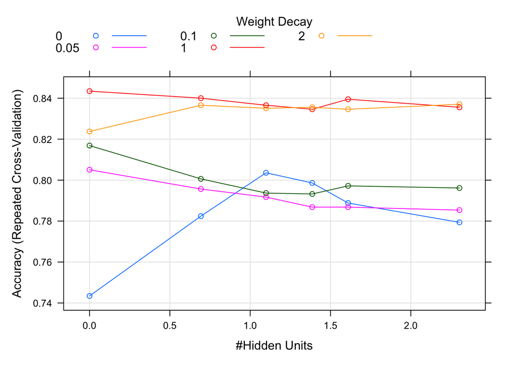

```r
plot(fit_acc_cat_nnet_tune, xTrans = log)
```

## Random forest

```r
set.seed(12341)
fit_acc_cat_rf_tune <- train(obs ~ .,
                     data = standard_df_all,
                     method = "rf",
                     metric = my_metric,
                     trControl = my_ctrl,
                     tuneGrid = expand.grid(mtry = seq(2, 8, by = 1)),
                     importance = TRUE)

fit_acc_cat_rf_tune
```

```
## Random Forest
##
## 677 samples
##  35 predictor
##   2 classes: 'event', 'non_event'
##
## No pre-processing
## Resampling: Cross-Validated (5 fold, repeated 3 times)
## Summary of sample sizes: 542, 542, 541, 542, 541, 541, ...
## Resampling results across tuning parameters:
##
##   mtry  Accuracy   Kappa
##   2     0.8207516  0.2363886
##   3     0.8168192  0.2351729
##   4     0.8212418  0.2758946
##   5     0.8163108  0.2658852
##   6     0.8163036  0.2699581
##   7     0.8177705  0.2727664
##   8     0.8148402  0.2731197
##
## Accuracy was used to select the optimal model using the largest value.
## The final value used for the model was mtry = 4.
```

## Gradient boosted tree

```r
set.seed(12341)
fit_acc_cat_gbm_warmup <- train(obs ~ .,
                      data = standard_df_all,
                      method = "gbm",
                      metric = my_metric,
                      trControl = my_ctrl,
                      verbose = FALSE)

fit_acc_cat_gbm_warmup
```

```
## Stochastic Gradient Boosting
##
## 677 samples
##  35 predictor
##   2 classes: 'event', 'non_event'
##
## No pre-processing
## Resampling: Cross-Validated (5 fold, repeated 3 times)
## Summary of sample sizes: 542, 542, 541, 542, 541, 541, ...
## Resampling results across tuning parameters:
##
##   interaction.depth  n.trees  Accuracy   Kappa
##   1                   50      0.8256754  0.2936665
##   1                  100      0.8261511  0.3227085
##   1                  150      0.8222259  0.3122151
##   2                   50      0.8148184  0.2808063
##   2                  100      0.8167865  0.3124378
##   2                  150      0.8168046  0.3211462
##   3                   50      0.8172948  0.3141616
##   3                  100      0.8094190  0.3073492
##   3                  150      0.8010167  0.2677713
##
## Tuning parameter 'shrinkage' was held constant at a value of 0.1
##
## Tuning parameter 'n.minobsinnode' was held constant at a value of 10
## Accuracy was used to select the optimal model using the largest value.
## The final values used for the model were n.trees = 100, interaction.depth =
##  1, shrinkage = 0.1 and n.minobsinnode = 10.
```

Visualize the result and finding best tuning parameters

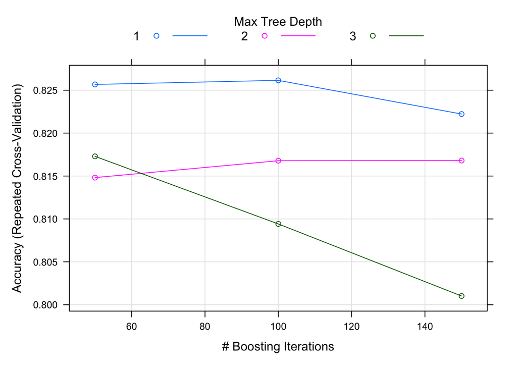

```r
plot(fit_acc_cat_gbm_warmup)
```

Tuning GBM model

```r
gbm_grid <- expand.grid(n.trees = c(100, 150, 300, 500, 750, 1000),
                        shrinkage = c(0.01, 0.1),
                        interaction.depth = fit_acc_cat_gbm_warmup$bestTune$interaction.depth,
                        n.minobsinnode = fit_acc_cat_gbm_warmup$bestTune$n.minobsinnode)

set.seed(12341)
fit_acc_cat_gbm_tune <- train(obs ~ .,
                      data = standard_df_all,
                      method = "gbm",
                      metric = my_metric,
                      tuneGrid = gbm_grid,
                      trControl = my_ctrl,
                      verbose=FALSE)
```

Check the result

```r
fit_acc_cat_gbm_tune
```

```
## Stochastic Gradient Boosting
##
## 677 samples
##  35 predictor
##   2 classes: 'event', 'non_event'
##
## No pre-processing
## Resampling: Cross-Validated (5 fold, repeated 3 times)
## Summary of sample sizes: 542, 542, 541, 542, 541, 541, ...
## Resampling results across tuning parameters:
##
##   shrinkage  n.trees  Accuracy   Kappa
##   0.01        100     0.8124183  0.00000000
##   0.01        150     0.8099528  0.04032359
##   0.01        300     0.8178250  0.22116142
##   0.01        500     0.8192810  0.25718224
##   0.01        750     0.8227306  0.29110840
##   0.01       1000     0.8222367  0.29354379
##   0.10        100     0.8227306  0.32083680
##   0.10        150     0.8197749  0.30105939
##   0.10        300     0.8103922  0.29634506
##   0.10        500     0.8069535  0.29829795
##   0.10        750     0.8045134  0.29545564
##   0.10       1000     0.8020443  0.30433567
##
## Tuning parameter 'interaction.depth' was held constant at a value of 1
##
## Tuning parameter 'n.minobsinnode' was held constant at a value of 10
## Accuracy was used to select the optimal model using the largest value.
## The final values used for the model were n.trees = 100, interaction.depth =
##  1, shrinkage = 0.1 and n.minobsinnode = 10.
```

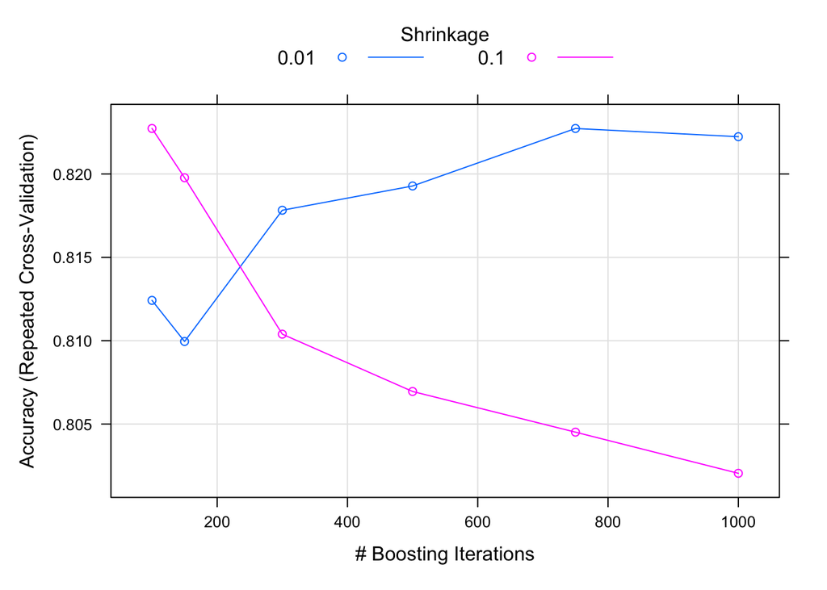

```r
plot(fit_acc_cat_gbm_tune)
```

## PLS

```r
pls_grid <- expand.grid(ncomp = 1:5)
set.seed(1024)
fit_acc_cat_cls_pls <- train(
  obs ~ .,
  data = standard_df_all,
  method = "pls",
  metric = my_metric,
  trControl = my_ctrl,
  tuneGrid = pls_grid,
  preProcess = c('center', 'scale')
)
```

## SVM

• 2 methods of your choice that we did not explicitly discuss in lecture

```r
set.seed(1024)
fit_acc_cat_svm_tune <- train(obs ~ .,
                 data = standard_df_all,
                 method = "svmRadial",
                 metric = my_metric,
                 preProcess = c("center", "scale"),
                 trControl = my_ctrl)

fit_acc_cat_svm_tune
```

```
## Support Vector Machines with Radial Basis Function Kernel
##
## 677 samples
##  35 predictor
##   2 classes: 'event', 'non_event'
##
## Pre-processing: centered (43), scaled (43)
## Resampling: Cross-Validated (5 fold, repeated 3 times)
## Summary of sample sizes: 542, 541, 542, 542, 541, 542, ...
## Resampling results across tuning parameters:
##
##   C     Accuracy   Kappa
##   0.25  0.8124183  0.000000000
##   0.50  0.8104539  0.005401644
##   1.00  0.8257298  0.185684276
##
## Tuning parameter 'sigma' was held constant at a value of 0.0170321
## Accuracy was used to select the optimal model using the largest value.
## The final values used for the model were sigma = 0.0170321 and C = 1.
```

# Model Evaluation

•You must identify the best model.

## Comparasion

```r
my_performance <- resamples(list(LM_1 = fit_acc_cat_lm_add,
                                 #LM_2 = fit_acc_cat_lm_pair,
                                 LM_MOD1 = fit_acc_cat_lm_mod1,
                                 LM_MOD2 = fit_acc_cat_lm_mod2,
                                 ENET_PAIR = fit_acc_cat_enet_pair,
                                 ENET_MOD7 = fit_acc_cat_enet_mod7,
                                 ENET_MOD9 = fit_acc_cat_enet_mod9,
                                 GBM_W = fit_acc_cat_gbm_warmup,
                                 GBN_T = fit_acc_cat_gbm_tune,
                                 NNET_W = fit_acc_cat_nnet_warmup,
                                 NNET_T = fit_acc_cat_nnet_tune,
                                 RF = fit_acc_cat_rf_tune,
                                 SVM = fit_acc_cat_svm_tune,
                                 PLS = fit_acc_cat_cls_pls
                                 )
                            )
```

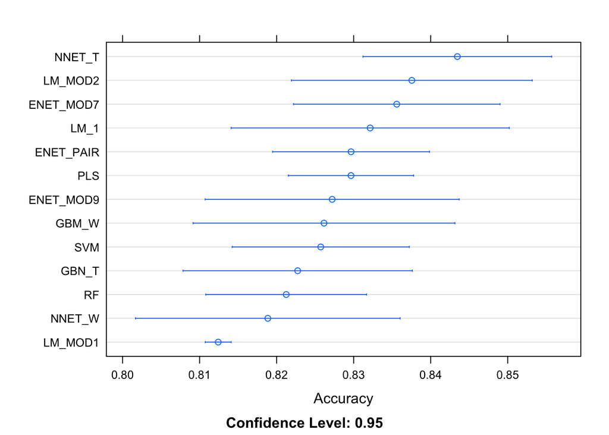

```r
dotplot(my_performance, metric = "Accuracy")
```

## Export model

```r
fit_acc_cat_lm_add %>% readr::write_rds('models/fit_acc_cat_lm_add.rds')
fit_acc_cat_lm_pair %>% readr::write_rds('models/fit_acc_cat_lm_pair.rds')
fit_acc_cat_lm_mod1 %>% readr::write_rds('models/fit_acc_cat_lm_mod1.rds')
fit_acc_cat_lm_mod2 %>% readr::write_rds('models/fit_acc_cat_lm_mod2.rds')
fit_acc_cat_enet_pair %>% readr::write_rds('models/fit_acc_cat_enet_pair.rds')
fit_acc_cat_enet_mod7 %>% readr::write_rds('models/fit_acc_cat_enet_mod7.rds')
fit_acc_cat_enet_mod9 %>% readr::write_rds('models/fit_acc_cat_enet_mod9.rds')
fit_acc_cat_gbm_warmup %>% readr::write_rds('models/fit_acc_cat_gbm_warmup.rds')
fit_acc_cat_gbm_tune %>% readr::write_rds('models/fit_acc_cat_gbm_tune.rds')
fit_acc_cat_nnet_warmup %>% readr::write_rds('models/fit_acc_cat_nnet_warmup.rds')
fit_acc_cat_nnet_tune %>% readr::write_rds('models/fit_acc_cat_nnet_tune.rds')
fit_acc_cat_rf_tune %>% readr::write_rds('models/fit_acc_cat_rf_tune.rds')
fit_acc_cat_svm_tune %>% readr::write_rds('models/fit_acc_cat_svm_tune.rds')
fit_acc_cat_cls_pls %>% readr::write_rds('models/fit_acc_cat_cls_pls.rds')
```